# IT5100F Final Report: E-Commerce Orders

# Group 5

**Report - Executive Summary**

This project analyzes an e-commerce dataset to uncover purchasing patterns, predict payment behavior, and generate actionable insights. The workflow integrates data preprocessing, exploratory data analysis (EDA), supervised learning, unsupervised learning, and market basket analysis to support data-driven decision-making in online retail:

**Assignment 1 – Data Preprocessing and EDA:** Data loading, table joining, handling missing values and invalid records, sanity checks, feature engineering, data storage, and exploratory analysis.

**Assignment 2 – Supervised Learning:** Data preparation, train–test split, categorical encoding, feature scaling, model training, evaluation, and model selection.

**Assignment 3 – Unsupervised Learning and Market Basket Analysis:** Creation of `all_orders_df` and `orders_analysis_df`, elbow method and K-Means clustering, market basket preparation, Apriori algorithm, and association rule generation and interpretation.

# Assignment 1: Data Preprocessing and EDA for E‑Commerce Orders

- Load **four tables** (`orders`, `order_items`, `order_shipping`, `payments`).
- Join them into a single order-level dataset.
- Clean and transform the data.
- Perform basic EDA and visualization.

## Setup

Run the cell below to import the required Python packages.

```python
import numpy as np
import pandas as pd
import matplotlib.pyplot as plt
import sklearn
import seaborn as sns

plt.style.use('seaborn-v0_8')
```

## Part 1: Data Preprocessing (10 marks)

### 1.1 Data Loading & Joining (4 marks)

We first load each table, inspect it, and then join them into a single DataFrame.

**Report - Setup**

We import standard libraries for data manipulation (pandas, numpy), visualization (matplotlib, seaborn), and later analysis. Loading the four CSVs (orders, order_items, order_shipping, payments) gives us the raw building blocks; joining them later produces a single order-level view for cleaning and modeling.

#### Load the CSV files

**Task:**

- Dowload the four CSV files from canvas and upload them under the 'files' tab for this colab instance
- Load the four CSV files using `pd.read_csv()` into:
  - `df_orders`
  - `df_order_items`
  - `df_shipping`
  - `df_payments`

Update the filenames/paths if necessary.

```python
# ANSWER: load the CSV files
df_orders = pd.read_csv('orders.csv')
df_order_items = pd.read_csv('order_items.csv')
df_shipping = pd.read_csv('order_shipping.csv')
df_payments = pd.read_csv('payments.csv')
```

#### Inspect each table

**Task:**

- For **each** DataFrame, display:
  - `head()` (first 5 rows)
  - `shape` (rows, columns)

This helps you understand the raw structure before joining.

```python
# ANSWER: inspect the DataFrames
df_orders.head()
```

|  | order_id | order_status | order_purchase_hour | order_purchase_dayofweek | order_purchase_month | order_total_value |
| --- | --- | --- | --- | --- | --- | --- |
| 0 | sdv-id-whzjUX | shipped | 10 | 4 | 4 | 744.312535 |
| 1 | sdv-id-gqShVM | delivered | 19 | 2 | 4 | 1030.521912 |
| 2 | sdv-id-vtaqcY | delivered | 18 | 4 | 8 | 28.472994 |
| 3 | sdv-id-xkqwdo | invoiced | 23 | 1 | 8 | 143.914263 |
| 4 | sdv-id-sGyHvQ | delivered | 19 | 0 | 2 | 16.944537 |

```python
df_orders.shape
```

```
(100000, 6)
```

```python
df_order_items.head()
```

|  | order_id | num_items | num_unique_products | num_unique_sellers | total_item_price | avg_item_price | total_freight_value | top_product_category |
| --- | --- | --- | --- | --- | --- | --- | --- | --- |
| 0 | sdv-id-whzjUX | 1 | 1 | 1 | 352.420029 | 369.966521 | 68.790159 | construction_tools_construction |
| 1 | sdv-id-gqShVM | 1 | 1 | 1 | 1580.187928 | 1089.284136 | 84.603289 | auto |
| 2 | sdv-id-vtaqcY | 1 | 1 | 1 | 45.969263 | 36.969754 | 24.022637 | furniture_decor |
| 3 | sdv-id-xkqwdo | 1 | 1 | 1 | 146.023435 | 126.755360 | 16.945349 | consoles_games |
| 4 | sdv-id-sGyHvQ | 1 | 1 | 1 | 30.525812 | 22.797409 | 17.785846 | air_conditioning |

```python
df_order_items.shape
```

```
(100000, 8)
```

```python
df_shipping.head()
```

|  | order_id | customer_state |
| --- | --- | --- |
| 0 | sdv-id-whzjUX | Massachusetts |
| 1 | sdv-id-gqShVM | Ohio |
| 2 | sdv-id-vtaqcY | Wisconsin |
| 3 | sdv-id-xkqwdo | Michigan |
| 4 | sdv-id-sGyHvQ | Nevada |

```python
df_shipping.shape
```

```
(100000, 2)
```

```python
df_payments.head()
```

|  | order_id | payment_type |
| --- | --- | --- |
| 0 | sdv-id-whzjUX | voucher |
| 1 | sdv-id-gqShVM | voucher |
| 2 | sdv-id-vtaqcY | voucher |
| 3 | sdv-id-xkqwdo | credit_card |
| 4 | sdv-id-sGyHvQ | credit_card |

```python
df_payments.shape
```

```
(100000, 2)
```

#### Join the tables on `order_id` to create a single order-level DataFrame

**Task:**

- Perform **inner joins** on `order_id` so that only orders present in **all** tables remain.
- Join order tables in this order:
  1. `df_orders` with `df_order_items`
  2. result with `df_shipping`
  3. result with `df_payments`
- Store the final DataFrame as `df_orders_full`.
- Display `head()` and `shape` for `df_orders_full`.

```python
# ANSWER: join the tables
df_orders_full = pd.merge(
    df_orders,
    df_order_items,
    on='order_id',
    how='inner'
)

df_orders_full = pd.merge(
    df_orders_full,
    df_shipping,
    on='order_id',
    how='inner'
)

df_orders_full = pd.merge(
    df_orders_full,
    df_payments,
    on='order_id',
    how='inner'
)

df_orders_full.head()
```

|  | order_id | order_status | order_purchase_hour | order_purchase_dayofweek | order_purchase_month | order_total_value | num_items | num_unique_products | num_unique_sellers | total_item_price | avg_item_price | total_freight_value | top_product_category | customer_state | payment_type |
| --- | --- | --- | --- | --- | --- | --- | --- | --- | --- | --- | --- | --- | --- | --- | --- |
| 0 | sdv-id-whzjUX | shipped | 10 | 4 | 4 | 744.312535 | 1 | 1 | 1 | 352.420029 | 369.966521 | 68.790159 | construction_tools_construction | Massachusetts | voucher |
| 1 | sdv-id-gqShVM | delivered | 19 | 2 | 4 | 1030.521912 | 1 | 1 | 1 | 1580.187928 | 1089.284136 | 84.603289 | auto | Ohio | voucher |
| 2 | sdv-id-vtaqcY | delivered | 18 | 4 | 8 | 28.472994 | 1 | 1 | 1 | 45.969263 | 36.969754 | 24.022637 | furniture_decor | Wisconsin | voucher |
| 3 | sdv-id-xkqwdo | invoiced | 23 | 1 | 8 | 143.914263 | 1 | 1 | 1 | 146.023435 | 126.755360 | 16.945349 | consoles_games | Michigan | credit_card |
| 4 | sdv-id-sGyHvQ | delivered | 19 | 0 | 2 | 16.944537 | 1 | 1 | 1 | 30.525812 | 22.797409 | 17.785846 | air_conditioning | Nevada | credit_card |

**Report - Joining Tables**

We use **inner joins** on `order_id` so that only orders present in all four tables are kept. This avoids errors like missing shipping or payment information and ensures a consistent, analyzable unit (one row = one order with full context).

*Business objective:* A single `df_orders_full` supports reliable analytics and ML (e.g., payment prediction, clustering) without incomplete records.

```python
df_orders_full.shape
```

```
(100000, 15)
```

### 1.2 Data Cleaning (3 marks)

We now clean `df_orders_full` so it is ready for analysis.

#### Handle missing values

**Task:**

- For **numerical** columns: replace missing values with the **median** of that column.
- For **categorical** columns: replace missing values with the **mode** (most frequent value).
- Drop any rows where `order_id` or `payment_type` is missing (if any remain)

Work directly on `df_orders_full`.

```python
# ANSWER: Handle missing values
df_orders_full.info()
```

```
<class 'pandas.core.frame.DataFrame'>
RangeIndex: 100000 entries, 0 to 99999
Data columns (total 15 columns):
 #   Column                    Non-Null Count   Dtype
---  ------                    --------------   -----
 0   order_id                  100000 non-null  object
 1   order_status              100000 non-null  object
 2   order_purchase_hour       100000 non-null  int64
 3   order_purchase_dayofweek  100000 non-null  int64
 4   order_purchase_month      100000 non-null  int64
 5   order_total_value         100000 non-null  float64
 6   num_items                 100000 non-null  int64
 7   num_unique_products       100000 non-null  int64
 8   num_unique_sellers        100000 non-null  int64
 9   total_item_price          100000 non-null  float64
 10  avg_item_price            99228 non-null   float64
 11  total_freight_value       100000 non-null  float64
 12  top_product_category      88444 non-null   object
 13  customer_state            100000 non-null  object
 14  payment_type              99678 non-null   object
dtypes: float64(4), int64(6), object(5)
memory usage: 11.4+ MB
```

```python
# Identify numerical and categorical columns
num_cols = df_orders_full.select_dtypes(include=['int64', 'float64']).columns
cat_cols = df_orders_full.select_dtypes(include=['object']).columns
```

```python
for col in num_cols:
    df_orders_full[col] = df_orders_full[col].fillna(
        df_orders_full[col].median()
    )

for col in cat_cols:
    df_orders_full[col] = df_orders_full[col].fillna(
        df_orders_full[col].mode()[0]
    )
```

```python
df_orders_full.dropna(subset=['order_id', 'payment_type'], inplace=True)
```

```python
df_orders_full.info()
```

```
<class 'pandas.core.frame.DataFrame'>
RangeIndex: 100000 entries, 0 to 99999
Data columns (total 15 columns):
 #   Column                    Non-Null Count   Dtype
---  ------                    --------------   -----
 0   order_id                  100000 non-null  object
 1   order_status              100000 non-null  object
 2   order_purchase_hour       100000 non-null  int64
 3   order_purchase_dayofweek  100000 non-null  int64
 4   order_purchase_month      100000 non-null  int64
 5   order_total_value         100000 non-null  float64
 6   num_items                 100000 non-null  int64
 7   num_unique_products       100000 non-null  int64
 8   num_unique_sellers        100000 non-null  int64
 9   total_item_price          100000 non-null  float64
 10  avg_item_price            100000 non-null  float64
 11  total_freight_value       100000 non-null  float64
 12  top_product_category      100000 non-null  object
 13  customer_state            100000 non-null  object
 14  payment_type              100000 non-null  object
dtypes: float64(4), int64(6), object(5)
memory usage: 11.4+ MB
```

**Report - Missing Values**

To ensure the integrity of subsequent data analysis, missing values were addressed during the preprocessing stage. Numerical missing values were imputed using the median to maintain robustness against outliers, while categorical gaps were filled with the mode. Rows missing critical identifiers, such as `order_id` or `payment_type`, were removed to ensure the dataset remains valid for future modeling and predictive tasks.

#### Remove clearly invalid numeric records

**Task:**

- Remove rows where:
  - `num_items` ≤ 0, or
  - `order_total_value` ≤ 0, or
  - `total_item_price` < 0, or
  - `total_freight_value` < 0.

**Report - Invalid Records**

To ensure the integrity of subsequent data analysis, invalid values were addressed during the preprocessing stage.

Rows with `num_items ≤ 0`, `order_total_value ≤ 0`, or negative item/freight values are removed because they represent impossible or erroneous transactions.

```python
# ANSWER: filter invalid numeric records
df_orders_full = df_orders_full[
    (df_orders_full['num_items'] > 0) &
    (df_orders_full['order_total_value'] > 0) &
    (df_orders_full['total_item_price'] >= 0) &
    (df_orders_full['total_freight_value'] >= 0)
]
```

#### Check cleanliness and key uniqueness

**Task:**

- Confirm there are **no null values** in `df_orders_full`.
- Check that `order_id` is unique (one row per order).

```python
# ANSWER: final cleaning checks
print("Total null values after cleaning:")
print(df_orders_full.isnull().sum().sum())

print("Are all order_id values unique?")
print(df_orders_full['order_id'].is_unique)
```

```
Total null values after cleaning:
0
Are all order_id values unique?
True
```

### 1.3 Data Transformation (3 marks)

Next, we perform sanity checks and create new features that will be useful later.

#### Sanity checks on counts and values

**Task:**

- Keep only rows where both:
  - `num_items` ≥ `num_unique_products`,
  - `order_total_value` ≥ `total_item_price + total_freight_value`

**Report - Sanity Check**

To ensure the integrity of subsequent data analysis, we filter out unresaonable values.

```python
# ANSWER: apply sanity checks
df_orders_full = df_orders_full[
    (df_orders_full['num_items'] >= df_orders_full['num_unique_products']) &
    (df_orders_full['order_total_value'] >= (df_orders_full['total_item_price'] + df_orders_full['total_freight_value']))
]

print(f"Rows remaining after sanity checks: {len(df_orders_full)}")
```

```
Rows remaining after sanity checks: 46287
```

#### Create `order_value_per_item`

**Task:**

- Create a new column `order_value_per_item` defined as `total_item_price / num_items`.

```python
# ANSWER: create order_value_per_item
df_orders_full['order_value_per_item'] = df_orders_full['total_item_price'] / df_orders_full['num_items']
```

```python
df_orders_full[['order_id', 'total_item_price', 'num_items', 'order_value_per_item']].head()
```

|  | order_id | total_item_price | num_items | order_value_per_item |
| --- | --- | --- | --- | --- |
| 0 | sdv-id-whzjUX | 352.420029 | 1 | 352.420029 |
| 5 | sdv-id-dbopoJ | 289.242639 | 1 | 289.242639 |
| 8 | sdv-id-FSEOvM | 26.893468 | 1 | 26.893468 |
| 12 | sdv-id-bQcBUR | 37.790896 | 1 | 37.790896 |
| 14 | sdv-id-MPxIXB | 169.528323 | 3 | 56.509441 |

#### Create `order_size_category`

**Task:**

- Create a new categorical column `order_size_category` with values:
  - "Small" if `num_items` ≤ 2
  - "Medium" if `num_items` ≤ 5
  - "Large" if `num_items` > 5

```python
# ANSWER: create order_size_category
def categorize_order_size(num_items):
    if num_items <= 2:
        return "Small"
    elif num_items <= 5:
        return "Medium"
    else:
        return "Large"

df_orders_full['order_size_category'] = df_orders_full['num_items'].apply(categorize_order_size)
```

```python
df_orders_full[['order_size_category']].head()
```

|  | order_size_category |
| --- | --- |
| 0 | Small |
| 5 | Small |
| 8 | Small |
| 12 | Small |
| 14 | Medium |

**Report - New Features**

We then create `order_value_per_item` (average value per item) and `order_size_category` (Small/Medium/Large) to support segmentation and prediction (e.g., payment type or basket analysis).

Business objective: Size categories and value-per-item help target marketing and understand order mix.

#### Final transformation check

**Task:**

- Confirm there are no null values in `df_orders_full`.
- Display:
  - `head()`
  - `shape`
  - `info()`

```python
# ANSWER: final transformation summary
df_orders_full.head()
```

|  | order_id | order_status | order_purchase_hour | order_purchase_dayofweek | order_purchase_month | order_total_value | num_items | num_unique_products | num_unique_sellers | total_item_price | avg_item_price | total_freight_value | top_product_category | customer_state | payment_type | order_value_per_item | order_size_category |
| --- | --- | --- | --- | --- | --- | --- | --- | --- | --- | --- | --- | --- | --- | --- | --- | --- | --- |
| 0 | sdv-id-whzjUX | shipped | 10 | 4 | 4 | 744.312535 | 1 | 1 | 1 | 352.420029 | 369.966521 | 68.790159 | construction_tools_construction | Massachusetts | voucher | 352.420029 | Small |
| 5 | sdv-id-dbopoJ | delivered | 19 | 2 | 3 | 1556.667902 | 1 | 1 | 1 | 289.242639 | 1354.621410 | 15.394619 | health_beauty | Vermont | credit_card | 289.242639 | Small |
| 8 | sdv-id-FSEOvM | delivered | 15 | 4 | 8 | 62.060506 | 1 | 1 | 1 | 26.893468 | 48.485654 | 18.751282 | luggage_accessories | South Carolina | debit_card | 26.893468 | Small |
| 12 | sdv-id-bQcBUR | delivered | 21 | 0 | 8 | 73.873470 | 1 | 1 | 1 | 37.790896 | 75.704909 | 8.670875 | computers_accessories | Kentucky | credit_card | 37.790896 | Small |
| 14 | sdv-id-MPxIXB | delivered | 13 | 5 | 5 | 361.961537 | 3 | 3 | 3 | 169.528323 | 50.132979 | 34.731146 | pet_shop | Missouri | voucher | 56.509441 | Medium |

```python
df_orders_full.shape
```

```
(46287, 17)
```

```python
df_orders_full.info()
```

```
<class 'pandas.core.frame.DataFrame'>
Index: 46287 entries, 0 to 99997
Data columns (total 17 columns):
 #   Column                    Non-Null Count  Dtype
---  ------                    --------------  -----
 0   order_id                  46287 non-null  object
 1   order_status              46287 non-null  object
 2   order_purchase_hour       46287 non-null  int64
 3   order_purchase_dayofweek  46287 non-null  int64
 4   order_purchase_month      46287 non-null  int64
 5   order_total_value         46287 non-null  float64
 6   num_items                 46287 non-null  int64
 7   num_unique_products       46287 non-null  int64
 8   num_unique_sellers        46287 non-null  int64
 9   total_item_price          46287 non-null  float64
 10  avg_item_price            46287 non-null  float64
 11  total_freight_value       46287 non-null  float64
 12  top_product_category      46287 non-null  object
 13  customer_state            46287 non-null  object
 14  payment_type              46287 non-null  object
 15  order_value_per_item      46287 non-null  float64
 16  order_size_category       46287 non-null  object
dtypes: float64(5), int64(6), object(6)
memory usage: 6.4+ MB
```

### 1.4 Data Storage

We now save the cleaned, joined, and transformed dataset.

#### 1.4A Save cleaned dataset

**Task:**

- Save `df_orders_full` as `ecommerce_orders_cleaned.csv` (without the index).

**Report - Data Storage**

To ensure a single source of truth and reproducible pipelines for Assignment 2 (supervised learning) and Assignment 3 (clustering and association mining), we save the cleaned dataset as `ecommerce_orders_cleaned.csv` (without index).

Business objective: Enable downstream modeling and reporting from one consistent, cleaned order-level table.

```python
# ANSWER: save to CSV
df_orders_full.to_csv('ecommerce_orders_cleaned.csv', index=False)
```

## Part 2: EDA & Data Visualization (4 marks)

We now reload the cleaned dataset and explore it.

### 2.0 Load Transformed Dataset

#### 2.0 Reload CSV

**Task:**

- Load `ecommerce_orders_cleaned.csv` into `df_orders_cleaned`.
- Display `head()` and `shape`.

**Report - EDA & Data Visualization**

The processed dataset was reloaded to generate visualizations and assess underlying distributions. EDA serves as a critical step in uncovering hidden patterns for predictive modeling and providing data-driven insights for business objectives. By utilizing clear labeling and standardized plotting techniques, the findings remain interpretable and accessible for all stakeholders.

```python
# ANSWER: load cleaned dataset
df_orders_cleaned = pd.read_csv('ecommerce_orders_cleaned.csv')
df_orders_cleaned.head()
```

|  | order_id | order_status | order_purchase_hour | order_purchase_dayofweek | order_purchase_month | order_total_value | num_items | num_unique_products | num_unique_sellers | total_item_price | avg_item_price | total_freight_value | top_product_category | customer_state | payment_type | order_value_per_item | order_size_category |
| --- | --- | --- | --- | --- | --- | --- | --- | --- | --- | --- | --- | --- | --- | --- | --- | --- | --- |
| 0 | sdv-id-whzjUX | shipped | 10 | 4 | 4 | 744.312535 | 1 | 1 | 1 | 352.420029 | 369.966521 | 68.790159 | construction_tools_construction | Massachusetts | voucher | 352.420029 | Small |
| 1 | sdv-id-dbopoJ | delivered | 19 | 2 | 3 | 1556.667902 | 1 | 1 | 1 | 289.242639 | 1354.621410 | 15.394619 | health_beauty | Vermont | credit_card | 289.242639 | Small |
| 2 | sdv-id-FSEOvM | delivered | 15 | 4 | 8 | 62.060506 | 1 | 1 | 1 | 26.893468 | 48.485654 | 18.751282 | luggage_accessories | South Carolina | debit_card | 26.893468 | Small |
| 3 | sdv-id-bQcBUR | delivered | 21 | 0 | 8 | 73.873470 | 1 | 1 | 1 | 37.790896 | 75.704909 | 8.670875 | computers_accessories | Kentucky | credit_card | 37.790896 | Small |
| 4 | sdv-id-MPxIXB | delivered | 13 | 5 | 5 | 361.961537 | 3 | 3 | 3 | 169.528323 | 50.132979 | 34.731146 | pet_shop | Missouri | voucher | 56.509441 | Medium |

```python
df_orders_cleaned.shape
```

```
(46287, 17)
```

### 2.1 Unique Categories and Payment Types (1 mark)

**Task:**

- Compute the number of unique values in `top_product_category` and `payment_type`.
- Display:
  - The top 5 product categories by order count.
  - The top 3 payment types by order count.

```python
# ANSWER: unique counts and top values
unique_categories = df_orders_cleaned['top_product_category'].nunique()
unique_payments = df_orders_cleaned['payment_type'].nunique()

print(f"Number of unique product categories: {unique_categories}")
print(f"Number of unique payment types: {unique_payments}")
print("-" * 50)

#Top 5 Product Categories
print("Top 5 Product Categories by Order Count:")
print(df_orders_cleaned['top_product_category'].value_counts().head(5))
print("-" * 50)

#Top 3 Payment Types
print("Top 3 Payment Types by Order Count:")
print(df_orders_cleaned['payment_type'].value_counts().head(3))
```

```
Number of unique product categories: 71
Number of unique payment types: 5
--------------------------------------------------
Top 5 Product Categories by Order Count:
top_product_category
bed_bath_table           6419
health_beauty            4208
furniture_decor          3413
computers_accessories    3386
telephony                2570
Name: count, dtype: int64
--------------------------------------------------
Top 3 Payment Types by Order Count:
payment_type
credit_card    27987
voucher        13812
points          2532
Name: count, dtype: int64
```

### 2.2 Bar Chart of Orders by Product Category (2 marks)

#### Create bar chart

**Task:**

- Create a bar chart of number of orders per `top_product_category`, sorted in descending order.
- Add a clear title and axis labels.

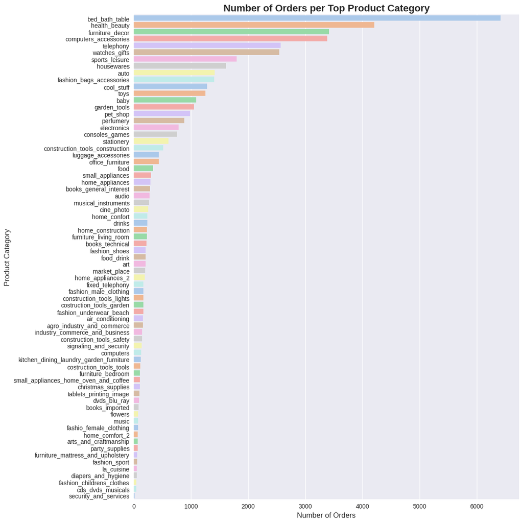

```python
# ANSWER: bar chart of product categories
category_counts = df_orders_cleaned['top_product_category'].value_counts()

plt.figure(figsize=(12, 12))
sns.barplot(
    x=category_counts.values,
    y=category_counts.index,
    hue=category_counts.index,
    palette='pastel',
    legend=False
)

plt.title('Number of Orders per Top Product Category', fontsize=16, fontweight='bold')
plt.xlabel('Number of Orders', fontsize=12)
plt.ylabel('Product Category', fontsize=12)

plt.tight_layout()
plt.savefig('orders_by_category.png')
```

#### Brief interpretation

**Task:**

- In 2–3 sentences, describe any trends you see (e.g., which categories dominate, whether the distribution is skewed, etc.).

The dataset shows a clear long tail pattern where a small number of popular categories account for most of the orders. Categories such as bed_bath_table and health_beauty dominate the sales volume, while order counts drop off quickly after the first few categories. Most of the remaining categories contribute relatively few orders and can be considered niche compared to the platform’s main drivers.

### 2.3 Box Plot: Order Value vs Number of Items (2 mark)

#### Create box plot

**Task:**

- Create a box plot with:
  - X‑axis: `num_items`
  - Y‑axis: `order_total_value`
- Add a clear title and axis labels.

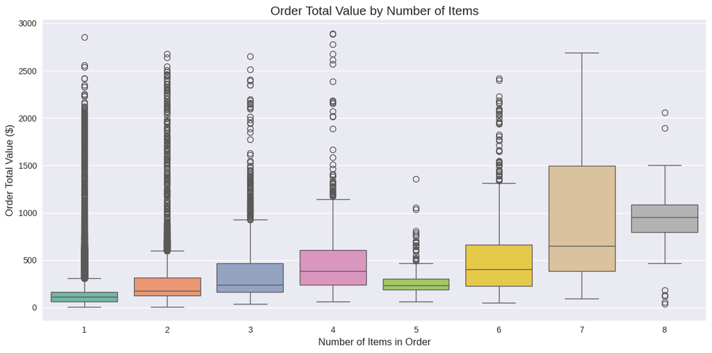

```python
# ANSWER: box plot order_total_value vs num_items
plt.figure(figsize=(12, 6))
sns.boxplot(
    data=df_orders_cleaned,
    x='num_items',
    y='order_total_value',
    hue='num_items',
    palette='Set2',
    legend=False
)


plt.title('Order Total Value by Number of Items', fontsize=15)
plt.xlabel('Number of Items in Order', fontsize=12)
plt.ylabel('Order Total Value ($)', fontsize=12)

plt.tight_layout()
plt.savefig('order_value_vs_items_boxplot.png')
```

#### Brief interpretation

**Task:**

- In 2–3 sentences, describe how order value changes as the number of items increases (e.g., linear trend, diminishing returns, many outliers, etc.).

As the number of items increases, the median order value generally trends upward, though there is a noticeable dip and tighter variance for orders containing exactly five items. There is considerable variation within each group, with many outliers indicating some orders have exceptionally high values regardless of item count. Overall, larger orders tend to have higher values but order value can vary widely for any given number of items.

# Assignment 2: Supervised Learning Techniques for E-Commerce Orders

This notebook is your working template for **Assignment 2**.

**Total Marks: 30**

**Learning Objectives:**

- Apply essential data preprocessing techniques to a dataset for supervised learning
- Prepare the data for classification modeling
- Apply supervised learning techniques to build and evaluate classification models

**Your Objective:** Build supervised classification models to predict the **payment method (`payment_type`)** used for each order, based on order characteristics and order attributes.

Work **top-to-bottom**. Complete each task in order before moving on.

**Report - Supervised Learning**

Supervised learning is applied because the task involves predicting a known categorical outcome, `payment_type`, from historical labeled order data. The models learn relationships between order characteristics and the payment method used, enabling prediction of payment preference for new orders.

*Business objective:* Predict customer payment preferences to support checkout optimization, targeted payment promotions, and payment method planning.

## Setup

Run the cell below to import the required Python packages.

```python
import pandas as pd
import numpy as np
import matplotlib.pyplot as plt
import seaborn as sns

from sklearn.model_selection import train_test_split
from sklearn.preprocessing import StandardScaler, LabelEncoder
from sklearn.linear_model import LogisticRegression
from sklearn.tree import DecisionTreeClassifier
from sklearn.ensemble import RandomForestClassifier
from sklearn.svm import SVC
from sklearn.metrics import accuracy_score, precision_score, recall_score, f1_score, confusion_matrix, classification_report

import warnings
warnings.filterwarnings('ignore')

plt.style.use('ggplot')
```

## Define Global Random State

Set your group's random state value. This must be used consistently throughout the assignment.

```python
# TODO: Set RANDOM_STATE to your group number (1, 2, ..., 12)
RANDOM_STATE = 5  # Change this to your group number

print(f"Random state set to: {RANDOM_STATE}")
```

```
Random state set to: 5
```

**Report — Data Preparation:**  
We use the cleaned dataset from Assignment 1 to build classification models that predict **payment_type** from order features. Proper preparation (train/test split, encoding, scaling) ensures models are evaluated on unseen data and that all inputs are in a form that algorithms can use.

*Business objective:* Predicting payment method supports fraud risk, checkout UX, and payment-method promotion.

# Part 1: Data Preparation [10 Marks]

In this section, you will prepare the transformed dataset for supervised classification. Proper data preparation is a critical step in the machine learning pipeline, as model performance and validity depend heavily on the quality, structure, and representation of the input data.

## 1.1 Data Loading and Splitting [2 Marks]

Load the dataset using Pandas and prepare train/test datasets.

**Instructions:**

1. Load the processed dataset from Assignment 1 using `pd.read_csv()`
2. Define features and target:
   - Set `payment_type` as the target variable
   - Set all remaining columns as input features
3. Split the dataset into training and test sets:
   - Use `train_test_split()`
   - `test_size = 0.2`
   - `random_state = RANDOM_STATE`
   - Name output variables as: `X_train`, `X_test`, `y_train`, `y_test`
4. Briefly explain the importance of using a test dataset.

```python
# Load the processed dataset from Assignment 1
# TODO: Adjust the filename/path if needed

df = pd.read_csv('ecommerce_orders_cleaned.csv')
print(f"Dataset shape: {df.shape}")
df.head()
```

```
Dataset shape: (46287, 17)
```

|  | order_id | order_status | order_purchase_hour | order_purchase_dayofweek | order_purchase_month | order_total_value | num_items | num_unique_products | num_unique_sellers | total_item_price | avg_item_price | total_freight_value | top_product_category | customer_state | payment_type | order_value_per_item | order_size_category |
| --- | --- | --- | --- | --- | --- | --- | --- | --- | --- | --- | --- | --- | --- | --- | --- | --- | --- |
| 0 | sdv-id-whzjUX | shipped | 10 | 4 | 4 | 744.312535 | 1 | 1 | 1 | 352.420029 | 369.966521 | 68.790159 | construction_tools_construction | Massachusetts | voucher | 352.420029 | Small |
| 1 | sdv-id-dbopoJ | delivered | 19 | 2 | 3 | 1556.667902 | 1 | 1 | 1 | 289.242639 | 1354.621410 | 15.394619 | health_beauty | Vermont | credit_card | 289.242639 | Small |
| 2 | sdv-id-FSEOvM | delivered | 15 | 4 | 8 | 62.060506 | 1 | 1 | 1 | 26.893468 | 48.485654 | 18.751282 | luggage_accessories | South Carolina | debit_card | 26.893468 | Small |
| 3 | sdv-id-bQcBUR | delivered | 21 | 0 | 8 | 73.873470 | 1 | 1 | 1 | 37.790896 | 75.704909 | 8.670875 | computers_accessories | Kentucky | credit_card | 37.790896 | Small |
| 4 | sdv-id-MPxIXB | delivered | 13 | 5 | 5 | 361.961537 | 3 | 3 | 3 | 169.528323 | 50.132979 | 34.731146 | pet_shop | Missouri | voucher | 56.509441 | Medium |

```python
# TODO: Define features and target, then split the data

# Define target variable
y = df['payment_type']

# Define features (all columns except payment_type)
X = df.drop('payment_type',axis=1)

# Split into train and test sets
X_train, X_test, y_train, y_test = train_test_split(X, y, test_size=0.2, random_state=RANDOM_STATE)

# Print shapes to verify
print(f"X_train shape: {X_train.shape}")
print(f"X_test shape: {X_test.shape}")
print(f"y_train shape: {y_train.shape}")
print(f"y_test shape: {y_test.shape}")
```

```
X_train shape: (37029, 16)
X_test shape: (9258, 16)
y_train shape: (37029,)
y_test shape: (9258,)
```

**TODO: Briefly explain the importance of using a test dataset.**

Test data can be utilized for model performance evaluation to assess the model's ability to generalize to unseen data. This process facilitates the selection of models with the strongest generalization capabilities while preventing overfitting, where the model excessively fits the training data during the learning process.

## 1.2 Handling Categorical Variables [4 Marks]

Prepare categorical variables for machine learning.

**Instructions:**

1. Identify all categorical columns
2. Apply label encoding:
   - Use `LabelEncoder` from scikit-learn
3. Ensure consistency across train and test sets:
   - Fit encoders on training data only
   - Transform both train and test sets
   - Handle any unseen categories appropriately
4. Briefly explain why categorical encoding is required for machine learning models

```python
# TODO: Identify categorical columns

categorical_cols = X_train.select_dtypes(include=['object', 'category']).columns.tolist()
print(f"Categorical columns: {categorical_cols}")
```

```
Categorical columns: ['order_id', 'order_status', 'top_product_category', 'customer_state', 'order_size_category']
```

**Report — Categorical encoding:**  
Most sklearn classifiers expect numeric features; fitting on train only keeps evaluation unbiased. We apply **LabelEncoder** to categorical columns (e.g. order_status, top_product_category, customer_state), fitting only on the training set and mapping test categories to the same labels (unseen categories get a sentinel value). This avoids data leakage and ensures models receive numeric inputs.

```python
# TODO: Apply Label Encoding to categorical columns

# Create copies to avoid modifying original data
X_train_encoded = X_train.copy()
X_test_encoded = X_test.copy()

# Dictionary to store label encoders for each column
label_encoders = {}

for col in categorical_cols:
    le = LabelEncoder()

    # Fit on training data
    le.fit(X_train_encoded[col].astype(str))

    # Transform train and test
    X_train_encoded[col] = le.transform(X_train_encoded[col].astype(str))

    # Handle unseen categories in test set
    classes_dict = {label: i for i, label in enumerate(le.classes_)}

    X_test_encoded[col] = X_test_encoded[col].astype(str).map(
        lambda x: classes_dict.get(x, -1)
    )

    # Store encoder
    label_encoders[col] = le

# Print the shape after encoding
print(f"X_train_encoded shape: {X_train_encoded.shape}")
print(f"X_test_encoded shape: {X_test_encoded.shape}")
```

```
X_train_encoded shape: (37029, 16)
X_test_encoded shape: (9258, 16)
```

**TODO: Briefly explain why categorical encoding is required for machine learning models.**

Category encoding is essential because most classification algorithms, such as logistic regression, cannot directly process string or object-type data. Encoding converts non-numeric features into numerical values, enabling the model to compute mathematical relationships between features and the target variable.

## 1.3 Handling Numerical Variables [4 Marks]

Scale numerical variables for modeling.

**Instructions:**

1. Identify all numerical columns
2. Use `StandardScaler` from scikit-learn for feature scaling
3. **Fit the scaler on X_train only**
4. Transform both X_train and X_test
5. Briefly explain why feature scaling is important for some classification models

```python
# TODO: Identify numerical columns

numerical_cols = X_train_encoded.select_dtypes(include=['int64', 'float64']).columns.tolist()
print(f"Numerical columns: {numerical_cols}")
```

[output not shown]

**Report — Numerical scaling**  
We **standardize** numerical features (zero mean, unit variance) using `StandardScaler` fitted on the training set, then transform both train and test. This puts features on comparable scales so distance-based and gradient-based models (e.g. Logistic Regression, SVM) are not dominated by high-magnitude columns.

*Business objective:* Better-scaled data improves model convergence and payment-type prediction quality.

```python
# TODO: Apply StandardScaler to numerical columns

scaler = StandardScaler()

# Fit on training data only, then transform both train and test
X_train_scaled = X_train_encoded.copy()
X_test_scaled = X_test_encoded.copy()

# Only scale numerical columns
if numerical_cols:
    # Fit scaler on training data only
    scaler.fit(X_train_encoded[numerical_cols])

    # Transform both training and test data
    X_train_scaled[numerical_cols] = scaler.transform(X_train_encoded[numerical_cols])
    X_test_scaled[numerical_cols] = scaler.transform(X_test_encoded[numerical_cols])

    print(f"Scaled {len(numerical_cols)} numerical columns")
else:
    print("No numerical columns found for scaling")

# Print the shape after scaling
print(f"X_train_scaled shape: {X_train_scaled.shape}")
print(f"X_test_scaled shape: {X_test_scaled.shape}")
```

```
Scaled 16 numerical columns
X_train_scaled shape: (37029, 16)
X_test_scaled shape: (9258, 16)
```

```python
X_combined = pd.concat([X_train_scaled, X_test_scaled])

# Save to CSV
X_combined.to_csv('processed_data.csv', index=False)

print("File saved successfully!")
```

```
File saved successfully!
```

*Business objective:* Identifying a high-performing and stable model is essential for practical applications such as payment optimization. Once validated, the model can be integrated into the checkout interface to provide personalized payment recommendations, reducing friction and supporting marketing strategy.

**TODO: Briefly explain why feature scaling is important for some classification models.**

Feature scaling is crucial for models that rely on distance metrics or weight updates (such as Logistic Regression). Should features exhibit vastly differing numerical ranges, those with extreme values will dominate the loss function, resulting in slow model training or biased predictions.

# Part 2: Applying Machine Learning Models [20 Marks]

In this section, you will train, evaluate, and compare multiple supervised classification models for predicting the payment method (`payment_type`). The objective is not only to build individual models, but also to perform a systematic comparison of their predictive performance and practical suitability for deployment.

## 2.1 Model Training

### 2.1.1 Logistic Regression [3 Marks]

Logistic Regression is a linear classification model that models the log-odds of the target class as a linear combination of the input features.

**Instructions:**

- Use `LogisticRegression()`
- Train on `X_train`, `y_train`
- Generate predictions on `X_test`
- Store the results in `y_pred_lr`

```python
# TODO: Train Logistic Regression model

lr_model = LogisticRegression(random_state=RANDOM_STATE, max_iter=1000)
lr_model.fit(X_train_scaled, y_train)

# Generate predictions
y_pred_lr = lr_model.predict(X_test_scaled)

print("Logistic Regression training complete.")
```

```
Logistic Regression training complete.
```

### 2.1.2 Decision Trees [3 Marks]

Decision Trees is a tree-structured model that makes predictions by recursively splitting the feature space based on feature values.

**Instructions:**

- Use `DecisionTreeClassifier()`
- Train on `X_train`, `y_train`
- Generate predictions on `X_test`
- Store the results in `y_pred_dt`

```python
# TODO: Train Decision Tree model

dt_model = DecisionTreeClassifier(random_state=RANDOM_STATE)
dt_model.fit(X_train_scaled, y_train)

# Generate predictions
y_pred_dt = dt_model.predict(X_test_scaled)

print("Decision Tree training complete.")
```

```
Decision Tree training complete.
```

### 2.1.3 Kernel & Ensemble Methods [3 Marks]

There are other types of models beyond linear and single-tree approaches, each with distinct characteristics.

**Choose one of the following models to apply:** SVM, XGBoost, or Random Forest.

**Instructions:**

- Fit and predict the results with your selected model
- Store the predictions appropriately

**Report — Evaluation and Model Selection**  
We evaluate using accuracy, precision, recall, F1, and confusion matrices. Comparing metrics across models (and across classes) shows which payment types are easier to predict and where errors concentrate. The final recommendation balances accuracy, interpretability, and business needs.

*Business objective:* Choose a model that generalizes well and supports actionable decisions. Practical applications for the selected model include risk mitigation through payment filtering and user experience optimization during the checkout process.

```python
# TODO: Train your chosen model (SVM, XGBoost, or Random Forest)
rf_model = RandomForestClassifier(random_state=RANDOM_STATE, n_estimators=100)
rf_model.fit(X_train_scaled, y_train)
y_pred_rf = rf_model.predict(X_test_scaled)
```

## 2.2 Evaluation & Visualization [4 Marks]

Evaluate and visualize performance for all three models.

**Instructions:**

1. Compute the following metrics:
   - Accuracy
   - Precision
   - Recall
   - F1-score
2. Compute the confusion matrix for each case:
   - Visualize the confusion matrix by plotting a heatmap using Seaborn
3. Present results in a clear, comparable format:
   - Table of metrics for all three models
   - Side-by-side or clearly labelled confusion matrix plots
4. Briefly comment on:
   - Strengths and weaknesses of each model
   - Any impact of class imbalance handling

```python
# TODO: Compute evaluation metrics for all three models

def evaluate_model(y_true, y_pred, model_name):
    accuracy = accuracy_score(y_true, y_pred)
    precision = precision_score(y_true, y_pred, average='weighted')
    recall = recall_score(y_true, y_pred, average='weighted')
    f1 = f1_score(y_true, y_pred, average='weighted')

    return {
        'Model': model_name,
        'Accuracy': accuracy,
        'Precision': precision,
        'Recall': recall,
        'F1-Score': f1
    }

# Evaluate all models
results = [
    evaluate_model(y_test, y_pred_lr, 'Logistic Regression'),
    evaluate_model(y_test, y_pred_dt, 'Decision Tree'),
    evaluate_model(y_test, y_pred_rf, 'Random Forest')  # or your chosen model
]

# Create results DataFrame
results_df = pd.DataFrame(results)
results_df
```

|  | Model | Accuracy | Precision | Recall | F1-Score |
| --- | --- | --- | --- | --- | --- |
| 0 | Logistic Regression | 0.605854 | 0.551183 | 0.605854 | 0.482675 |
| 1 | Decision Tree | 0.450313 | 0.488285 | 0.450313 | 0.465442 |
| 2 | Random Forest | 0.612659 | 0.562028 | 0.612659 | 0.560524 |

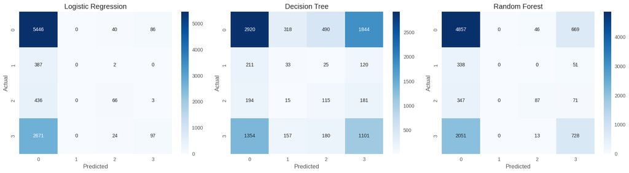

```python
# TODO: Plot confusion matrices for all three models

fig, axes = plt.subplots(1, 3, figsize=(18, 5))

def plot_confusion_matrix(y_true, y_pred, ax, title):
    cm = confusion_matrix(y_true, y_pred)
    sns.heatmap(cm, annot=True, fmt='d', cmap='Blues', ax=ax)
    ax.set_title(title)
    ax.set_xlabel('Predicted')
    ax.set_ylabel('Actual')

plot_confusion_matrix(y_test, y_pred_lr, axes[0], 'Logistic Regression')
plot_confusion_matrix(y_test, y_pred_dt, axes[1], 'Decision Tree')
plot_confusion_matrix(y_test, y_pred_rf, axes[2], 'Random Forest')  # or your chosen model

plt.tight_layout()
plt.show()
```

**TODO: Briefly comment on the strengths and weaknesses of each model, and any impact of class imbalance handling.**

Logistic Regression Strengths: High interpretability with clear coefficient meanings for each feature. Fast training and prediction, suitable for real-time applications. Works well with linearly separable data. Weakness： Can be affected by outliers in the data. May struggle with complex non-linear patterns in payment behavior.

Decision Tree Strengths: Handles both numerical and categorical features naturally. Robust to outliers. Can capture non-linear relationships and feature interactions. Weakness： Prone to overfitting, especially with deep trees. Can be unstable - small data changes may result in different trees.

Random Forest Strengths: Reduces overfitting compared to individual decision trees. Provides feature importance rankings. Generally robust to class imbalance through ensemble averaging. Weakness: Less interpretable than single decision trees. Can still overfit with very noisy data. Memory intensive and slower than simpler models.

Class Imbalance Impact: Regarding class imbalance, which is frequent in e-commerce data, relying solely on accuracy can be misleading. Models often become biased toward the majority class, leading to poor recall for minority classes. By applying handling strategies such as setting class weights to balanced, the model can better identify rare payment types.

## 2.3 Model Selection & Final Recommendation [7 Marks]

Compare the performance of the models and select the most suitable one based on evaluation results.

**Instructions:**

1. Select the best performing model for predicting `payment_type`
2. Justify your choice based on:
   - Evaluation metrics
   - Class imbalance considerations
   - Model complexity and interpretability
   - Practical deployment considerations
3. Briefly explain why this model is preferred over the others
4. Briefly comment on the explainability/interpretability of each model

```python
# TODO: Display final comparison and analysis

# Display the results table
print("Model Performance Comparison:")
print(results_df.to_string(index=False))

# Identify the best model based on your criteria
best_model = results_df.loc[results_df['F1-Score'].idxmax(), 'Model']
print(f"\nBest performing model: {best_model}")
```

```
Model Performance Comparison:
              Model  Accuracy  Precision   Recall  F1-Score
Logistic Regression  0.605854   0.551183 0.605854  0.482675
      Decision Tree  0.450313   0.488285 0.450313  0.465442
      Random Forest  0.612659   0.562028 0.612659  0.560524

Best performing model: Random Forest
```

### Final Recommendation

**TODO: Select and justify your choice of the best model.**

**Selected Model:** Random Forest

**Why this model is preferred over others:** Random Forest is preferred because it delivers the most balanced performance between precision and recall, ensuring high predictive power without sacrificing reliability.

### Model Explainability/Interpretability

**TODO: Comment on the explainability/interpretability of each model.**

**Logistic Regression:** Logistic Regression offers high interpretability as it establishes a linear relationship by assigning weights to each feature. We can directly observe the magnitude and sign of these coefficients to determine the direction and strength of a feature's influence on the prediction

**Decision Tree:** The interpretability of decision trees stems from their intuitive simulation of human decision-making processes. Instead of complex mathematical coefficients, we can directly trace the decision paths and feature splits to understand how the model arrives at a specific prediction. This allows us to identify which features are most significant in the classification process and observe the specific thresholds that influence payment method selection.

**Random Forest:** Random forests exhibit relatively low interpretability, as they comprise hundreds or thousands of decision trees with randomised parameters, making it difficult to observe their internal decision-making processes. Consequently, they are less transparent than individual decision trees, and we cannot trace individual prediction paths as we can with single decision trees.

## Conclusion

Through this assignment, we systematically implemented the full machine learning workflow from raw data to predictive models. Using an e-commerce order dataset, we constructed and compared three typical supervised learning models: Logistic Regression, Decision Tree, and the ensemble model Random Forest, aiming to accurately predict the payment method for orders.

Data preprocessing proved critical to model performance. We discovered that before tackling classification tasks, categorical variables must undergo label encoding and numerical features require standardisation to effectively prevent model collapse.

The final experimental results provided a clear and intuitive comparison of the predictive capabilities across different models. Among these, Random Forest achieved the highest test scores. However, comprehensive model selection must still be conducted from the perspective of business interpretability.

# Project (Assignment 3): Unsupervised Learning (E-Commerce Orders)

This notebook is your working template for **Assignment 3**.

**Note:** This assessment comprises two parts: question-guided processing/modeling (Unsupervised learning) and free-form exploration.

**Total Marks: 20**

You will:

- Continue working with the expanded dataset from Assignment 1
- Perform **clustering** to identify similar order types
- Apply **market basket analysis** (association rule mining)
- Write up findings throughout the notebook
- Publish your analysis as a github.io page

Work **top-to-bottom**. Complete each task in order before moving on.

## Setup

Run the cell below to import the required Python packages.

```python
import pandas as pd
import numpy as np
import matplotlib.pyplot as plt
import seaborn as sns

from sklearn.model_selection import train_test_split
from sklearn.preprocessing import StandardScaler
from sklearn.cluster import KMeans

from mlxtend.preprocessing import TransactionEncoder
from mlxtend.frequent_patterns import apriori, association_rules

plt.style.use('seaborn-v0_8')
```

## Load Your Cleaned Dataset from Assignment 1

Load the cleaned and expanded dataset you created in Assignment 1 (and potentially modified in Assignment 2).

```python
# ANSWER: Load your cleaned dataset
df = pd.read_csv('ecommerce_orders_cleaned.csv')

# Display basic information about the dataset
print(f"Dataset shape: {df.shape}")
print(f"\nColumn names:\n{df.columns.tolist()}")
print(f"\nFirst 5 rows:")
df.head()
```

```
Dataset shape: (46287, 17)

Column names:
['order_id', 'order_status', 'order_purchase_hour', 'order_purchase_dayofweek', 'order_purchase_month', 'order_total_value', 'num_items', 'num_unique_products', 'num_unique_sellers', 'total_item_price', 'avg_item_price', 'total_freight_value', 'top_product_category', 'customer_state', 'payment_type'…

First 5 rows:
```

|  | order_id | order_status | order_purchase_hour | order_purchase_dayofweek | order_purchase_month | order_total_value | num_items | num_unique_products | num_unique_sellers | total_item_price | avg_item_price | total_freight_value | top_product_category | customer_state | payment_type | order_value_per_item | order_size_category |
| --- | --- | --- | --- | --- | --- | --- | --- | --- | --- | --- | --- | --- | --- | --- | --- | --- | --- |
| 0 | sdv-id-whzjUX | shipped | 10 | 4 | 4 | 744.312535 | 1 | 1 | 1 | 352.420029 | 369.966521 | 68.790159 | construction_tools_construction | Massachusetts | voucher | 352.420029 | Small |
| 1 | sdv-id-dbopoJ | delivered | 19 | 2 | 3 | 1556.667902 | 1 | 1 | 1 | 289.242639 | 1354.621410 | 15.394619 | health_beauty | Vermont | credit_card | 289.242639 | Small |
| 2 | sdv-id-FSEOvM | delivered | 15 | 4 | 8 | 62.060506 | 1 | 1 | 1 | 26.893468 | 48.485654 | 18.751282 | luggage_accessories | South Carolina | debit_card | 26.893468 | Small |
| 3 | sdv-id-bQcBUR | delivered | 21 | 0 | 8 | 73.873470 | 1 | 1 | 1 | 37.790896 | 75.704909 | 8.670875 | computers_accessories | Kentucky | credit_card | 37.790896 | Small |
| 4 | sdv-id-MPxIXB | delivered | 13 | 5 | 5 | 361.961537 | 3 | 3 | 3 | 169.528323 | 50.132979 | 34.731146 | pet_shop | Missouri | voucher | 56.509441 | Medium |

## Task: Unsupervised Learning

### Objective

In this task, you will work on unsupervised learning and support your analysis with visualization. Perform clustering to identify **similar orders** and generate **order type recommendations** based on their characteristics. An order type cluster represents a group of orders with similar purchasing patterns, value structures, and composition.

**Report – Unsupervised Learning**

Unsupervised learning techniques are applied to explore the dataset’s underlying structure without the constraints of labeled data. We use the same cleaned dataset from Assignment 1 to perform *clustering* (find similar order types) and *association rule mining* (find co-occurring product/payment patterns). The goal is to discover structure and actionable patterns.

*Business objective:* Segment orders for targeting and discover which categories or attributes tend to appear together for cross-sell and recommendations.

### 1: Data Preprocessing for Unsupervised Learning [1 Mark]

Goal: Create DataFrames that contain one row per order with features suitable for both clustering and association mining.

#### 1.1 Create `all_orders_df` (one row per order)

Create a new DataFrame called `all_orders_df` with the following columns:

Identifier:

- `order_id` — Unique identifier of the order
- `basket_size` — Monetary value of the order (from `order_total_value`)
- `basket_qty` — Number of items in the order (from `num_items`)
- `freight_ratio` — Proportion of the order value that is freight (computed as `total_freight_value / order_total_value`)
- `product_diversity` — How varied the basket is in terms of product types (computed as `num_unique_products / num_items`)
- `top_product_category` — The dominant product category in the order
- `payment_type` — The payment method used
- `order_size_category` — The order size category (Small/Medium/Large)

Notes:

- `all_orders_df` must have exactly one row per `order_id`.
- No missing values should remain in these columns after preprocessing (apply reasonable handling if needed).
- Handle potential division issues appropriately (e.g., orders with zero values).
- Display the first 10 rows of `all_orders_df`, its shape, and data types.

```python
# 1.1 ANSWER: Create all_orders_df

all_orders_df = pd.DataFrame()

all_orders_df['order_id'] = df['order_id']
all_orders_df['basket_size'] = df['order_total_value']
all_orders_df['basket_qty'] = df['num_items']
all_orders_df['freight_ratio'] = df['total_freight_value'] / df['order_total_value'].replace(0, np.nan)
all_orders_df['freight_ratio'] = all_orders_df['freight_ratio'].fillna(0)
all_orders_df['product_diversity'] = df['num_unique_products'] / df['num_items'].replace(0, np.nan)
all_orders_df['product_diversity'] = all_orders_df['product_diversity'].fillna(0)
all_orders_df['top_product_category'] = df['top_product_category']
all_orders_df['payment_type'] = df['payment_type']
all_orders_df['order_size_category'] = df['order_size_category']

# Display information
print(f"Shape of all_orders_df: {all_orders_df.shape}")
print(f"\nData types:\n{all_orders_df.dtypes}")
print(f"\nMissing values:\n{all_orders_df.isnull().sum()}")
print(f"\nFirst 10 rows:")
all_orders_df.head(10)
```

```
Shape of all_orders_df: (46287, 8)

Data types:
order_id                 object
basket_size             float64
basket_qty                int64
freight_ratio           float64
product_diversity       float64
top_product_category     object
payment_type             object
order_size_category      object
dtype: object

Missing values:
order_id                0
basket_size             0
basket_qty              0
freight_ratio           0
product_diversity       0
top_product_category    0
payment_type            0
order_size_category     0
dtype: int64

First 10 rows:
```

|  | order_id | basket_size | basket_qty | freight_ratio | product_diversity | top_product_category | payment_type | order_size_category |
| --- | --- | --- | --- | --- | --- | --- | --- | --- |
| 0 | sdv-id-whzjUX | 744.312535 | 1 | 0.092421 | 1.000000 | construction_tools_construction | voucher | Small |
| 1 | sdv-id-dbopoJ | 1556.667902 | 1 | 0.009889 | 1.000000 | health_beauty | credit_card | Small |
| 2 | sdv-id-FSEOvM | 62.060506 | 1 | 0.302145 | 1.000000 | luggage_accessories | debit_card | Small |
| 3 | sdv-id-bQcBUR | 73.873470 | 1 | 0.117375 | 1.000000 | computers_accessories | credit_card | Small |
| 4 | sdv-id-MPxIXB | 361.961537 | 3 | 0.095953 | 1.000000 | pet_shop | voucher | Medium |
| 5 | sdv-id-ySodbB | 867.750230 | 7 | 0.204442 | 0.857143 | sports_leisure | voucher | Large |
| 6 | sdv-id-wdwBrk | 55.965822 | 2 | 0.285101 | 0.500000 | toys | points | Small |
| 7 | sdv-id-maBYtk | 170.295452 | 3 | 0.089290 | 1.000000 | computers_accessories | voucher | Medium |
| 8 | sdv-id-oodUXj | 83.065603 | 1 | 0.236471 | 1.000000 | furniture_decor | voucher | Small |
| 9 | sdv-id-zroJIL | 98.250248 | 1 | 0.369709 | 1.000000 | fashion_bags_accessories | points | Small |

#### 1.2 Create `orders_analysis_df`

- Use `train_test_split` from sklearn to split the data in `all_orders_df`.
- Set `test_size=0.3` (keep 30% of data for analysis) and `random_state=37` for reproducibility.
- Assign the **test set** to the variable `orders_analysis_df`.

Display the shape of `orders_analysis_df` and show its first 10 rows.

**Report -- Create `orders_analysis_df`**

Transactional data was aggregated into an order-level dataset **all_orders_df**, featuring engineered metrics such as basket size, freight ratio, and product diversity to standardize order comparisons. To ensure model generalizability and prevent overfitting, a 30% holdout set **orders_analysis_df** was reserved. This partitioning strategy facilitates the validation of cluster stability across independent data samples.

```python
# 1.2 ANSWER: Create orders_analysis_df using train_test_split

train_df, orders_analysis_df = train_test_split(
    all_orders_df,
    test_size=0.3,
    random_state=37
)

# Display information
print(f"Shape of orders_analysis_df: {orders_analysis_df.shape}")
print(f"\nFirst 10 rows:")
orders_analysis_df.head(10)
```

```
Shape of orders_analysis_df: (13887, 8)

First 10 rows:
```

|  | order_id | basket_size | basket_qty | freight_ratio | product_diversity | top_product_category | payment_type | order_size_category |
| --- | --- | --- | --- | --- | --- | --- | --- | --- |
| 1882 | sdv-id-ISddRn | 132.611695 | 1 | 0.126285 | 1.000000 | christmas_supplies | voucher | Small |
| 40995 | sdv-id-GmlErp | 730.510053 | 6 | 0.075288 | 0.666667 | furniture_decor | credit_card | Large |
| 40104 | sdv-id-BWpket | 632.486142 | 1 | 0.051262 | 1.000000 | bed_bath_table | credit_card | Small |
| 25808 | sdv-id-krmbPT | 47.102393 | 1 | 0.248932 | 1.000000 | telephony | credit_card | Small |
| 23294 | sdv-id-vhfMmG | 133.285008 | 1 | 0.135860 | 1.000000 | health_beauty | debit_card | Small |
| 7160 | sdv-id-kcTYfM | 403.696187 | 2 | 0.079065 | 0.500000 | auto | credit_card | Small |
| 7180 | sdv-id-tFFFCg | 211.465148 | 2 | 0.162263 | 1.000000 | furniture_decor | voucher | Small |
| 20801 | sdv-id-KgDKAA | 57.520738 | 1 | 0.228879 | 1.000000 | bed_bath_table | credit_card | Small |
| 19879 | sdv-id-cfCjEB | 576.212699 | 3 | 0.056350 | 0.666667 | bed_bath_table | credit_card | Medium |
| 39874 | sdv-id-uxRZME | 141.772602 | 2 | 0.200719 | 1.000000 | fashion_bags_accessories | credit_card | Small |

### 2: Determine the Optimal Number of Clusters [3 Marks]

#### 2.1 Run K-Means for Different Cluster Numbers

- Use **only the four numerical features** from `orders_analysis_df` (`basket_size`, `basket_qty`, `freight_ratio`, `product_diversity`) for clustering.
- Run K-means clustering from **k = 3 to 9** clusters.
- Important: First scale the numerical features using `StandardScaler` before fitting K-means.
- In each run, calculate the **inertia** of the cluster and store the values for each k (3 to 9) in a list or table.

Inertia is a measure of how tightly packed the clusters are. It is the sum of squared distances between each point and its assigned cluster center (centroid). Lower inertia indicates that the clusters are more compact, and the points are closer to their centroids, suggesting better clustering.

```python
# 2.1 ANSWER: Run K-means for k=3 to 9 and calculate inertia

numerical_features = ['basket_size', 'basket_qty', 'freight_ratio', 'product_diversity']
X = orders_analysis_df[numerical_features]

scaler = StandardScaler()
X_scaled = scaler.fit_transform(X)

inertia_values = []
k_range = range(3, 10)

for k in k_range:
    kmeans = KMeans(n_clusters=k, random_state=42, n_init=10)
    kmeans.fit(X_scaled)
    inertia_values.append(kmeans.inertia_)
    print(f"k={k}: inertia={kmeans.inertia_:.2f}")

# Create a summary table
inertia_df = pd.DataFrame({
    'Number of Clusters (k)': list(k_range),
    'Inertia': inertia_values
})

print("\nSummary Table:")
inertia_df
```

```
k=3: inertia=28884.29
k=4: inertia=21464.38
k=5: inertia=17303.04
k=6: inertia=15014.04
k=7: inertia=13219.42
k=8: inertia=11762.52
k=9: inertia=10516.55

Summary Table:
```

|  | Number of Clusters (k) | Inertia |
| --- | --- | --- |
| 0 | 3 | 28884.290455 |
| 1 | 4 | 21464.384393 |
| 2 | 5 | 17303.035640 |
| 3 | 6 | 15014.036862 |
| 4 | 7 | 13219.424099 |
| 5 | 8 | 11762.521590 |
| 6 | 9 | 10516.550809 |

**Report – Optimal Clusters**

Numerical features were standardized to prevent variables with larger magnitudes from disproportionately influencing the **K-means** distance calculations. We run **K-Means** for several values of k and plot **inertia** (within-cluster sum of squares) against k. The **Elbow Method** (where inertia stops decreasing sharply) suggests a reasonable k. We then fit the final K-Means with that k to assign each order to a cluster.

#### 2.2 Elbow Method for Optimal Clusters

- Plot the **inertia** (y-axis) against the **number of clusters** (x-axis) to identify the optimal number of clusters using the **Elbow method**.

The Elbow Method helps in selecting the number of clusters by identifying where the inertia starts to decrease more slowly.

- Based on the Elbow plot, **choose the optimal number of clusters** and state your choice clearly.

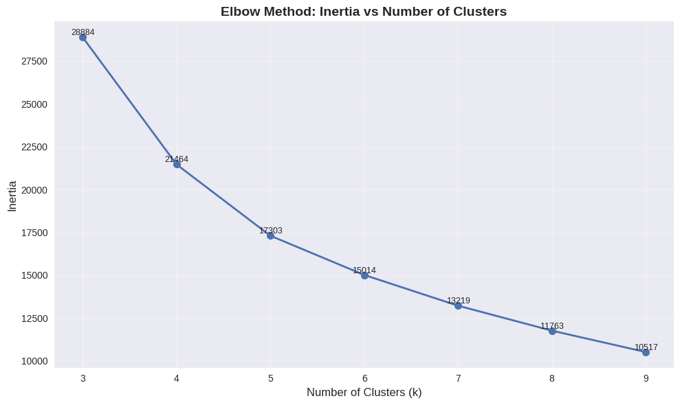

```python
# 2.2 ANSWER: Create Elbow plot

# Create the elbow plot
plt.figure(figsize=(10, 6))
plt.plot(k_range, inertia_values, marker='o', linewidth=2, markersize=8)
plt.xlabel('Number of Clusters (k)', fontsize=12)
plt.ylabel('Inertia', fontsize=12)
plt.title('Elbow Method: Inertia vs Number of Clusters', fontsize=14, fontweight='bold')
plt.grid(True, alpha=0.3)
plt.xticks(k_range)

# Add value labels on each point
for i, (k, inertia) in enumerate(zip(k_range, inertia_values)):
    plt.text(k, inertia, f'{inertia:.0f}',
             ha='center', va='bottom', fontsize=9)

plt.tight_layout()
plt.show()
```

Based on the plot above, choose optimal k = 5

```python
optimal_k = 5
```

### 3: Cluster Analysis and Visualization [3 Marks]

#### 3.1 Identify the Cluster Number for Each Order

- Create a K-means model using the four numerical features from `all_orders_df` and the optimal number of clusters identified in Task 2.
- Fit the model on the scaled numerical features.
- Use the fitted model to assign a cluster number to each order and add a new column called `cluster` to `all_orders_df`.
- Show the first 10 rows of `all_orders_df` to verify cluster assignment.

**Report - Cluster Analysis**

Since no predefined labels exist, we leverage cluster analysis to group similar orders based on the four numerical features. This allows us to discover and group possible e-commerce purchasing characteristics within the dataset.

*Business objective:* Identify groups of purchasing patterns to support targeted marketing strategies and improve the efficiency of marketing resource allocation.

```python
# 3.1 ANSWER: Fit K-means with optimal k and assign clusters

X_all = all_orders_df[numerical_features]

scaler_all = StandardScaler()
X_all_scaled = scaler_all.fit_transform(X_all)

kmeans_final = KMeans(n_clusters=optimal_k, random_state=42, n_init=10)
all_orders_df['cluster'] = kmeans_final.fit_predict(X_all_scaled)

print(f"Cluster assignment complete. Added 'cluster' column to all_orders_df.")
print(f"\nFirst 10 rows:")
all_orders_df.head(10)
```

```
Cluster assignment complete. Added 'cluster' column to all_orders_df.

First 10 rows:
```

|  | order_id | basket_size | basket_qty | freight_ratio | product_diversity | top_product_category | payment_type | order_size_category | cluster |
| --- | --- | --- | --- | --- | --- | --- | --- | --- | --- |
| 0 | sdv-id-whzjUX | 744.312535 | 1 | 0.092421 | 1.000000 | construction_tools_construction | voucher | Small | 1 |
| 1 | sdv-id-dbopoJ | 1556.667902 | 1 | 0.009889 | 1.000000 | health_beauty | credit_card | Small | 0 |
| 2 | sdv-id-FSEOvM | 62.060506 | 1 | 0.302145 | 1.000000 | luggage_accessories | debit_card | Small | 4 |
| 3 | sdv-id-bQcBUR | 73.873470 | 1 | 0.117375 | 1.000000 | computers_accessories | credit_card | Small | 1 |
| 4 | sdv-id-MPxIXB | 361.961537 | 3 | 0.095953 | 1.000000 | pet_shop | voucher | Medium | 1 |
| 5 | sdv-id-ySodbB | 867.750230 | 7 | 0.204442 | 0.857143 | sports_leisure | voucher | Large | 3 |
| 6 | sdv-id-wdwBrk | 55.965822 | 2 | 0.285101 | 0.500000 | toys | points | Small | 2 |
| 7 | sdv-id-maBYtk | 170.295452 | 3 | 0.089290 | 1.000000 | computers_accessories | voucher | Medium | 1 |
| 8 | sdv-id-oodUXj | 83.065603 | 1 | 0.236471 | 1.000000 | furniture_decor | voucher | Small | 4 |
| 9 | sdv-id-zroJIL | 98.250248 | 1 | 0.369709 | 1.000000 | fashion_bags_accessories | points | Small | 4 |

#### 3.2 Visualize the Clusters

Create two visualizations to understand your clusters:

- **Visualization 1: Cluster Profile Heatmap**
  - Visualize the cluster profiles using a heatmap to understand the average characteristics of each segment.
  - Step 1: Compute the mean of the four numerical features (`basket_size`, `basket_qty`, `freight_ratio`, `product_diversity`) for each cluster.
  - Step 2: Scale these means (e.g., using `StandardScaler` to calculate Z-scores) so that different units (price vs. count) can be compared directly.
  - Step 3: Plot the scaled means as a heatmap:
    - X-axis: Cluster number
    - Y-axis: Feature name
    - Color: Use a diverging colormap (e.g., `RdBu_r`) to distinguish features that are above average (positive Z-score) from those that are below average (negative Z-score)
    - Annotation: Display the Z-score values in each cell
  - Add a clear title.
- **Visualization 2: Cluster Size Distribution**
  - Create a bar chart showing the number of orders in each cluster.
    - X-axis: Cluster number (0, 1, 2, ...)
    - Y-axis: Count of orders
    - This helps you understand if clusters are balanced or if some clusters dominate.
  - Add a title and axis labels.

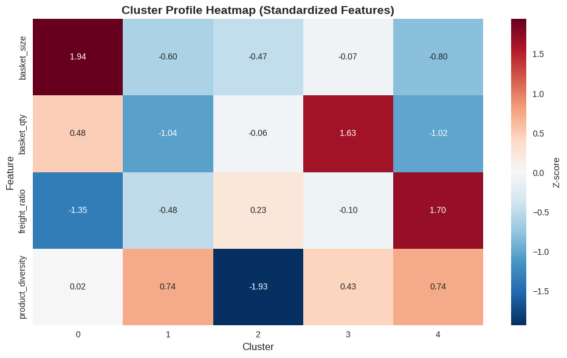

```python
# 3.2 ANSWER: Visualization 1 - Cluster profile heatmap

cluster_means = all_orders_df.groupby('cluster')[numerical_features].mean()

scaler_heatmap = StandardScaler()
cluster_means_scaled = scaler_heatmap.fit_transform(cluster_means)
cluster_means_scaled_df = pd.DataFrame(
    cluster_means_scaled,
    index=cluster_means.index,
    columns=cluster_means.columns
)

plt.figure(figsize=(10, 6))
sns.heatmap(
    cluster_means_scaled_df.T,
    annot=True,
    fmt='.2f',
    cmap='RdBu_r',
    center=0,
    cbar_kws={'label': 'Z-score'}
)
plt.title('Cluster Profile Heatmap (Standardized Features)', fontsize=14, fontweight='bold')
plt.xlabel('Cluster', fontsize=12)
plt.ylabel('Feature', fontsize=12)
plt.tight_layout()
plt.show()
```

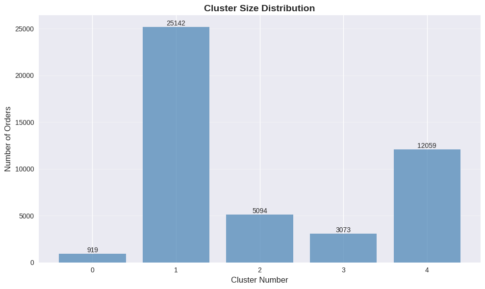

```python
# 3.2 ANSWER: Visualization 2 - Cluster size distribution

cluster_counts = all_orders_df['cluster'].value_counts().sort_index()

plt.figure(figsize=(10, 6))
plt.bar(cluster_counts.index, cluster_counts.values, color='steelblue', alpha=0.7)
plt.xlabel('Cluster Number', fontsize=12)
plt.ylabel('Number of Orders', fontsize=12)
plt.title('Cluster Size Distribution', fontsize=14, fontweight='bold')
plt.xticks(cluster_counts.index)
plt.grid(axis='y', alpha=0.3)

for i, v in enumerate(cluster_counts.values):
    plt.text(cluster_counts.index[i], v, str(v), ha='center', va='bottom', fontsize=10)

plt.tight_layout()
plt.show()
```

**Briefly comment (2-3 sentences) on:**

- How well separated do the clusters appear based on the heatmap?
- Which features seem to have the most significant impact on defining the clusters? Why might this be the case?
- Based on the visualizations that you have generated, comment on the nature of the clusters and what it implies for an e-commerce business

**3.2 ANSWER:**

Cluster Separation and Significant Features:

Nature of Clusters and Business Implications:

The visualizations identify several actionable order segments:

Cluster 0 (Premium Orders): High-value orders with very low freight ratios. These represent "VIP" transactions where the shipping cost is negligible compared to the basket value.

Cluster 3 (High-Volume/Quantity): Orders with a high number of items (Z = 1.63).

Cluster 4 (High Logistics Cost): Orders where freight represents a disproportionately high part of the value. For an e-commerce business, these insights imply the need for differentiated strategies, such as offering loyalty rewards for Cluster 0 and optimizing shipping bundles or setting higher free-shipping thresholds for Cluster 4 to improve profit margins.

Cluster Size Distribution:

The distribution shows that Cluster 1 is the dominant segment (25,142 orders), representing the "standard" or typical transaction for the platform. In contrast, Cluster 0 (919 orders) is a niche but high-value segment. Understanding this balance allows the business to allocate resources efficiently, focusing high-touch customer service on the premium minority while automating processes for the high-volume majority.

### 4: Market Basket Analysis (Association Rule Mining) [8 Marks]

#### 4.1 Context: What is Market Basket Analysis?

Market Basket Analysis is an unsupervised learning technique that identifies which products, categories, or attributes are frequently observed together. In e-commerce, this helps answer questions such as:

- "Which payment methods are preferred for which product categories?"
- "Do certain order sizes correlate with specific product types?"
- "What are the multi-dimensional patterns across category, payment, and order size?"

Association rules are commonly described using three key metrics:

- **Support**: How frequently a pattern occurs (0-1 scale)
- **Confidence**: Likelihood of the consequent given the antecedent (0-1 scale)
- **Lift**: How much more likely the rule is compared to random chance (> 1 indicates a positive association)

The Apriori algorithm discovers frequent itemsets and then generates association rules from them.

In this task, you will perform Market Basket Analysis using the categorical features from `all_orders_df` to discover multi-dimensional associations between product category, payment type, and order size category.

**Report - Market Basket Analysis**

This analysis is used to discover which attributes frequently appear in an order, helping us reveal purchasing patterns across the dataset. We treat each order as a **transaction** of items (e.g. product category, payment type, size category). After encoding transactions into a binary matrix, we run the **Apriori** algorithm to find frequent itemsets, then derive **association rules** (antecedent → consequent) with support, confidence, and lift.

*Business objective:* Enable cross-selling, bundling, and targeted promotions based on common purchase combinations.

#### 4.2 Prepare Transaction Data [1 Mark]

Convert each order in `all_orders_df` into a simple "basket" representation.

Create a Python list called `transactions`, where each element represents one order and contains exactly three string items constructed from that order:

- `cat_{top_product_category}` (e.g., `cat_electronics`, `cat_furniture_decor`)
- `pay_{payment_type}` (e.g., `pay_credit_card`, `pay_boleto`)
- `size_{order_size_category}` (e.g., `size_Small`, `size_Large`)

After constructing `transactions`, display the first 5 transactions to verify the format.

```python
# 4.2 ANSWER: Create transaction list

transactions = []

for _, row in all_orders_df.iterrows():
    transaction = [
        f"cat_{row['top_product_category']}",
        f"pay_{row['payment_type']}",
        f"size_{row['order_size_category']}"
    ]
    transactions.append(transaction)

print(f"Total transactions: {len(transactions)}")
print(f"\nFirst 5 transactions:")
for i in range(5):
    print(f"Transaction {i+1}: {transactions[i]}")
```

```
Total transactions: 46287

First 5 transactions:
Transaction 1: ['cat_construction_tools_construction', 'pay_voucher', 'size_Small']
Transaction 2: ['cat_health_beauty', 'pay_credit_card', 'size_Small']
Transaction 3: ['cat_luggage_accessories', 'pay_debit_card', 'size_Small']
Transaction 4: ['cat_computers_accessories', 'pay_credit_card', 'size_Small']
Transaction 5: ['cat_pet_shop', 'pay_voucher', 'size_Medium']
```

#### 4.3 Encode Transactions and Apply Apriori Algorithm [2 Marks]

Use the `mlxtend` library to discover frequent itemsets and generate association rules.

- Step 1: Encode transactions using `TransactionEncoder` and display the shape of the encoded DataFrame.
- Step 2: Apply `apriori()` with `min_support = 0.01` and `use_colnames = True`, then display the number of frequent itemsets found.
- Step 3: Generate association rules using `association_rules()` with `metric = 'lift'` and `min_threshold = 1.0`, then display the number of rules generated.

```python
# 4.3 ANSWER: Step 1 - Encode transactions

te = TransactionEncoder()
te_ary = te.fit(transactions).transform(transactions)
transactions_df = pd.DataFrame(te_ary, columns=te.columns_)

print(f"Encoded transactions shape: {transactions_df.shape}")
print(f"Number of unique items: {transactions_df.shape[1]}")
print(f"\nFirst 5 rows of encoded transactions:")
transactions_df.head()
```

```
Encoded transactions shape: (46287, 79)
Number of unique items: 79

First 5 rows of encoded transactions:
```

|  | cat_agro_industry_and_commerce | cat_air_conditioning | cat_art | cat_arts_and_craftmanship | cat_audio | cat_auto | cat_baby | cat_bed_bath_table | cat_books_general_interest | cat_books_imported | ... | cat_toys | cat_watches_gifts | pay_credit_card | pay_debit_card | pay_not_defined | pay_points | pay_voucher | size_Large | size_Medium | size_Small |
| --- | --- | --- | --- | --- | --- | --- | --- | --- | --- | --- | --- | --- | --- | --- | --- | --- | --- | --- | --- | --- | --- |
| 0 | False | False | False | False | False | False | False | False | False | False | ... | False | False | False | False | False | False | True | False | False | True |
| 1 | False | False | False | False | False | False | False | False | False | False | ... | False | False | True | False | False | False | False | False | False | True |
| 2 | False | False | False | False | False | False | False | False | False | False | ... | False | False | False | True | False | False | False | False | False | True |
| 3 | False | False | False | False | False | False | False | False | False | False | ... | False | False | True | False | False | False | False | False | False | True |
| 4 | False | False | False | False | False | False | False | False | False | False | ... | False | False | False | False | False | False | True | False | True | False |

5 rows × 79 columns

```python
# 4.3 ANSWER: Step 2 - Apply Apriori

frequent_itemsets = apriori(transactions_df, min_support=0.01, use_colnames=True)

print(f"Number of frequent itemsets found: {len(frequent_itemsets)}")
print(f"\nTop 10 frequent itemsets by support:")

frequent_itemsets.sort_values('support', ascending=False).head(10)
```

```
Number of frequent itemsets found: 102

Top 10 frequent itemsets by support:
```

|  | support | itemsets |
| --- | --- | --- |
| 26 | 0.864735 | (size_Small) |
| 20 | 0.604641 | (pay_credit_card) |
| 75 | 0.528118 | (size_Small, pay_credit_card) |
| 23 | 0.298399 | (pay_voucher) |
| 80 | 0.250805 | (size_Small, pay_voucher) |
| 2 | 0.138678 | (cat_bed_bath_table) |
| 34 | 0.111349 | (size_Small, cat_bed_bath_table) |
| 25 | 0.098149 | (size_Medium) |
| 31 | 0.097695 | (cat_bed_bath_table, pay_credit_card) |
| 11 | 0.090911 | (cat_health_beauty) |

**Report - Interpreting Association Rules**

We sort rules by lift (or confidence) and display the top rules. **Lift > 1** means the consequent appears more often with the antecedent than in general; **lift > 1.5** is often treated as a strong association. The top patterns (as in 4.5) summarize which categories, payment types, or sizes tend to co-occur—directly informing promotions and product placement.

```python
# 4.3 ANSWER: Step 3 - Generate association rules

rules = association_rules(frequent_itemsets, metric='lift', min_threshold=1.0)

print(f"Number of association rules generated: {len(rules)}")
print(f"\nSample of rules:")
rules.head()
```

```
Number of association rules generated: 138

Sample of rules:
```

|  | antecedents | consequents | antecedent support | consequent support | support | confidence | lift | representativity | leverage | conviction | zhangs_metric | jaccard | certainty | kulczynski |
| --- | --- | --- | --- | --- | --- | --- | --- | --- | --- | --- | --- | --- | --- | --- |
| 0 | (cat_auto) | (pay_credit_card) | 0.030592 | 0.604641 | 0.020503 | 0.670198 | 1.108423 | 1.0 | 0.002006 | 1.198777 | 0.100904 | 0.033352 | 0.165817 | 0.352053 |
| 1 | (pay_credit_card) | (cat_auto) | 0.604641 | 0.030592 | 0.020503 | 0.033909 | 1.108423 | 1.0 | 0.002006 | 1.003433 | 0.247414 | 0.033352 | 0.003422 | 0.352053 |
| 2 | (pay_credit_card) | (cat_baby) | 0.604641 | 0.023592 | 0.015015 | 0.024833 | 1.052604 | 1.0 | 0.000750 | 1.001273 | 0.126403 | 0.024486 | 0.001271 | 0.330640 |
| 3 | (cat_baby) | (pay_credit_card) | 0.023592 | 0.604641 | 0.015015 | 0.636447 | 1.052604 | 1.0 | 0.000750 | 1.087487 | 0.051182 | 0.024486 | 0.080449 | 0.330640 |
| 4 | (size_Small) | (cat_baby) | 0.864735 | 0.023592 | 0.020913 | 0.024184 | 1.025108 | 1.0 | 0.000512 | 1.000607 | 0.181074 | 0.024110 | 0.000607 | 0.455316 |

#### 4.4 Extract and Display Top 10 Rules [1 Mark]

Sort the association rules by **lift** in descending order and display the top 10 rules in a table showing:

- Antecedents (left-hand side of rule)
- Consequents (right-hand side of rule)
- Support
- Confidence
- Lift

Example rule output and interpretation:

| antecedents | consequents | support | confidence | lift |
| --- | --- | --- | --- | --- |
| (cat_furniture_decor, size_Large) | (pay_credit_card) | 0.042 | 0.756 | 1.84 |

"Customers who purchase **furniture** in **large orders** have a **75.6% probability** (confidence) of paying with a **credit card**. This behavior is **1.84 times more likely** (lift) than the general probability of using a credit card.

```python
# 4.4 ANSWER: Display top 10 rules by lift

top_rules = rules.sort_values('lift', ascending=False).head(10)

top_rules_display = top_rules[['antecedents', 'consequents', 'support', 'confidence', 'lift']].copy()

print("Top 10 Association Rules by Lift:")
print("="*80)
top_rules_display
```

```
Top 10 Association Rules by Lift:
================================================================================
```

|  | antecedents | consequents | support | confidence | lift |
| --- | --- | --- | --- | --- | --- |
| 24 | (size_Large) | (cat_furniture_decor) | 0.014583 | 0.392899 | 5.328480 |
| 25 | (cat_furniture_decor) | (size_Large) | 0.014583 | 0.197773 | 5.328480 |
| 74 | (size_Medium, pay_credit_card) | (cat_bed_bath_table) | 0.016851 | 0.280576 | 2.023212 |
| 75 | (cat_bed_bath_table) | (size_Medium, pay_credit_card) | 0.016851 | 0.121514 | 2.023212 |
| 76 | (size_Medium) | (pay_credit_card, cat_bed_bath_table) | 0.016851 | 0.171693 | 1.757439 |
| 73 | (pay_credit_card, cat_bed_bath_table) | (size_Medium) | 0.016851 | 0.172490 | 1.757439 |
| 27 | (size_Medium) | (cat_furniture_decor) | 0.012660 | 0.128990 | 1.749354 |
| 26 | (cat_furniture_decor) | (size_Medium) | 0.012660 | 0.171696 | 1.749354 |
| 9 | (cat_bed_bath_table) | (size_Medium) | 0.022749 | 0.164044 | 1.671388 |
| 8 | (size_Medium) | (cat_bed_bath_table) | 0.022749 | 0.231785 | 1.671388 |

#### 4.5 Interpretation (3-4 sentences) [3 Marks]

Write a brief interpretation explaining:

- What the top 3 unique rules tell you about customer behavior
- Which combinations are most strongly associated (highest lift)
- Why these associations might exist (business intuition)
- Change the min_support value to 0.005 and 0.3 and comment on any changes in the rules identified

**4.5 ANSWER:**

The top 3 unique association patterns reveal distinct purchasing behaviors: (1) Large orders strongly associate with furniture(2) Medium-sized orders with credit card payments associate with bed/bath/table products. (3) Medium orders generally associate with furniture.

The strongest association is the furniture-large order combination with a lift of 5.33, which is exceptionally high and indicates furniture is 5.3 times more likely to appear in large orders than random chance.

This makes business sense because furniture items are inherently expensive and bulky, requiring significant shipping costs that inflate order values. The second-tier associations (lift ~1.7-2.0) involving bed/bath products and medium orders reflect household shopping patterns where customers bundle related items.

When changing min_support to 0.005 (lower threshold), the algorithm would discover more granular, niche associations including rare product combinations and specific category pairs, potentially revealing specialized customer segments but with lower statistical reliability. Conversely, setting min_support to 0.3 (higher threshold) would only capture the most common universal patterns like "credit_card + Small order" combinations, eliminating all category-specific insights shown above, as even the most frequent product category (bed_bath_table at 13.9% support) wouldn't meet this threshold. This demonstrates the trade-off between discovering actionable niche patterns versus focusing only on mass-market behaviors.

#### 4.6 Business Recommendations (2-3 bullet points) [1 Mark]

Based on the discovered associations, provide actionable business recommendations for an e-commerce firm.

**4.6 ANSWER:**

- **Implement furniture-focused upselling and cross-selling strategies**: Since large orders strongly correlate with furniture purchases (lift=5.33), create targeted product bundles that combine furniture with complementary items.
- **Optimize payment options and promotions for medium-value home essential purchases**: Given the strong association between credit card payments and medium-sized bed/bath/table orders (lift=2.02), partner with credit card companies to offer installment plans or bonus rewards points specifically for home essentials categories.
- **Develop category-specific inventory and logistics planning**: Use the discovered associations to optimize warehouse placement and shipping strategies—prioritize furniture stock in distribution centers with robust large-item handling capacity, while ensuring bed/bath inventory is readily available for medium-quantity orders.

**Report - Summary**

The steps and reasoning for the full pipeline are described in the Report notes placed inline above: **Assignment 1** (data loading, joining, missing values, invalid records, sanity checks, new features, storage, EDA); **Assignment 2** (data preparation, train/test split, categorical encoding, scaling, model training, evaluation and selection); **Assignment 3** (all_orders_df / orders_analysis_df, elbow method and K-Means clustering, market basket preparation, Apriori, association rules and interpretation).

#### Tips

- Rules with **lift > 1.5** are considered strong associations; rules with **lift > 2.0** are very strong.
- When writing interpretations, explain not just the statistical strength but also the **business logic** behind the patterns.